# Spatial Analysis

GESIS Workshop: Introduction to Geospatial Techniques for Social Scientists in R

Stefan Jünger, Anne Stroppe & Dennis Abel

2026-04-24

## Now

| Day | Time | Title |
| --- | --- | --- |
| April 09 | 10:00-11:30 | Introduction |
| April 09 | 11:30-11:45 | Coffee Break |
| April 09 | 11:45-13:00 | Data Formats |
| April 09 | 13:00-14:00 | Lunch Break |
| April 09 | 14:00-15:30 | Mapping |
| April 09 | 15:30-15:45 | Coffee Break |
| April 09 | 15:45-17:00 | Spatial Wrangling |
| April 10 | 09:00-10:30 | Spatial Wrangling |
| April 10 | 10:30-10:45 | Coffee Break |
| April 10 | 10:45-12:00 | Applied Spatial Linking |
| April 10 | 12:00-13:00 | Lunch Break |
| April 10 | 13:00-14:30 | Spatial Analysis |
| April 10 | 14:30-14:45 | Coffee Break |
| April 10 | 14:45-16:00 | Spatial Econometrics & Outlook |

## Thus far

We’ve done some wrangling, mapping, and linking of geospatial data (with georeferenced survey data)

We’ve seen that geospatial data are relevant to provide context and this context can be communicated with maps–we can tell a story!

**However, geospatial data can also be utilized to detect and analyze social processes**

## Tobler’s first law of geography

> [E]verything is related to everything else, but near things are more related than distant things (Tobler 1970, p. 236)<sup>1</sup>

This means nearby geographical regions, institutions, or people are more similar or have a stronger influence on each other.

**What we get is an interdependent system.**

[^1]: Tobler, W. R. (1970). A Computer Movie Simulating Urban Growth in the Detroit Region. Economic Geography, 46, 234–240. https://doi.org/10.2307/143141

## Spatial Interdependence

Tobler’s law is the fundamental principle of doing spatial analysis.

**Spatial autocorrelation** is the correlation of a variable with itself across space, conditional on a specified neighborhood or weights matrix.

We want to know

1. If observations in our data are spatially interdependent
2. And how this interdependence can be explained (= data generation process)

## Analyze spatial autocorrelation

Three crucial steps:

1. Define who is connected (**neighbourhood matrix**)
2. Define the (relative) strength of connectivity (**weights matrix**)
3. Compute **autocorrelation measures**

## Step 1: Model connectiveness

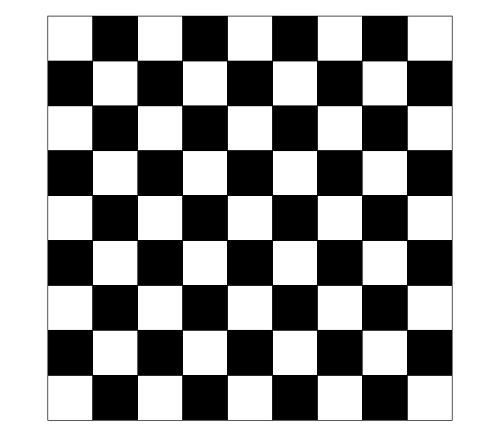

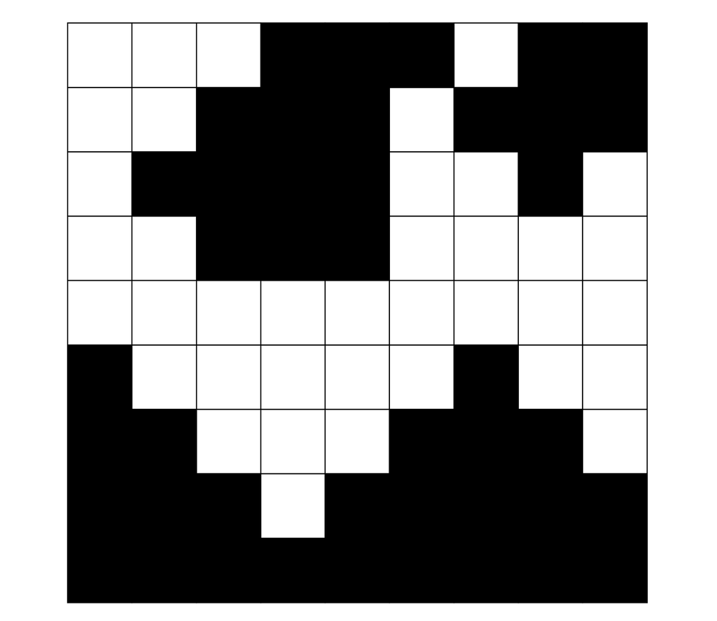

## Rook and queen neighborhoods

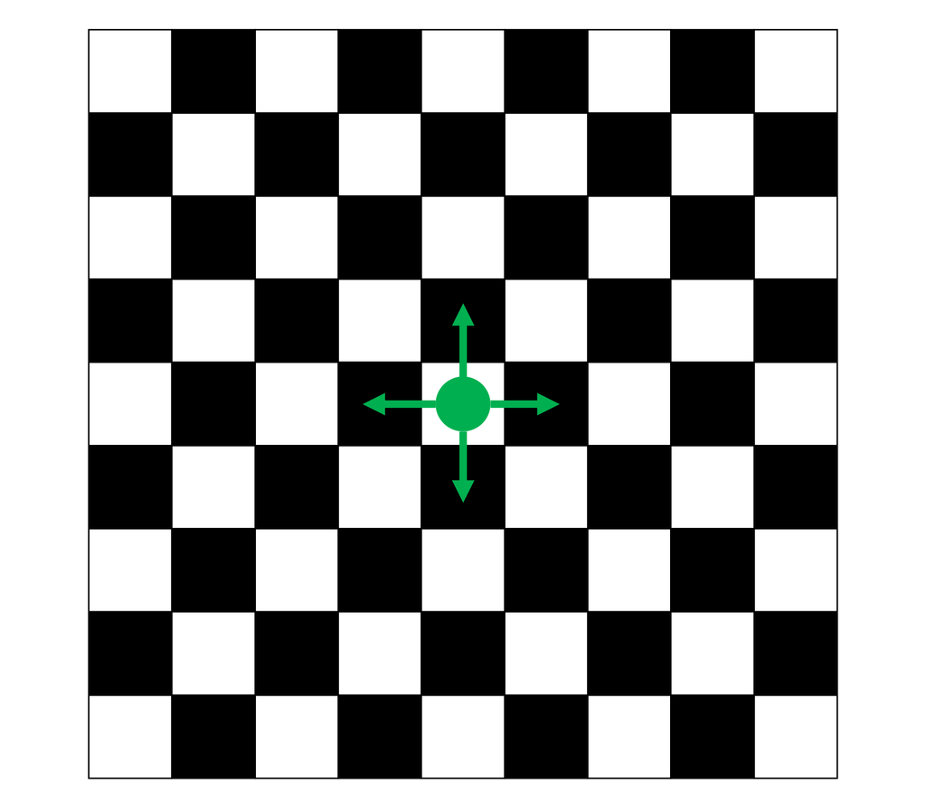

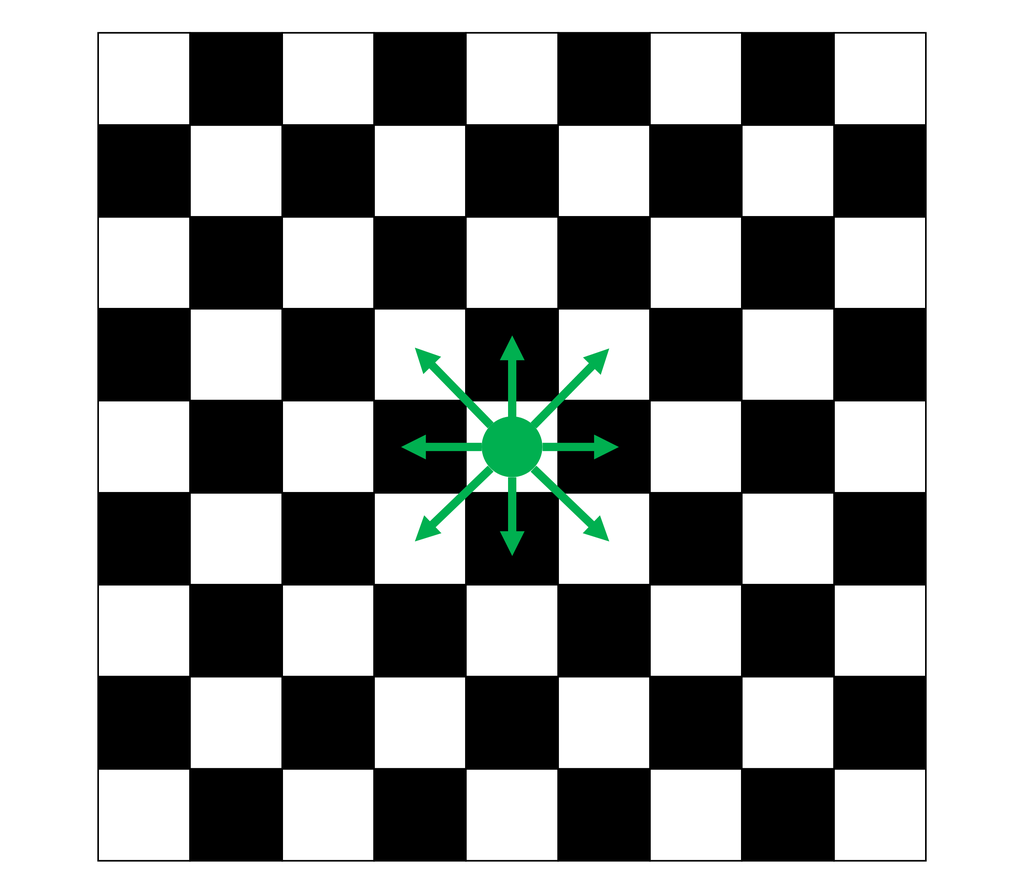

## It’s an interdependent system

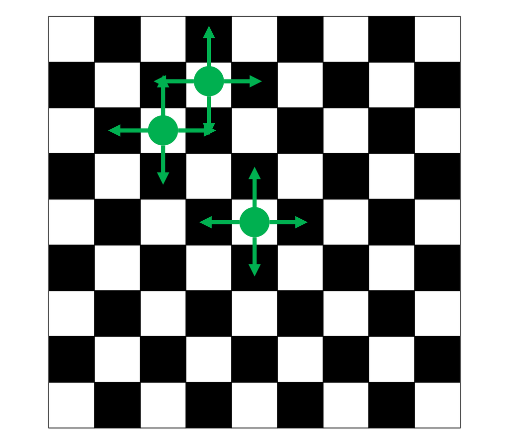

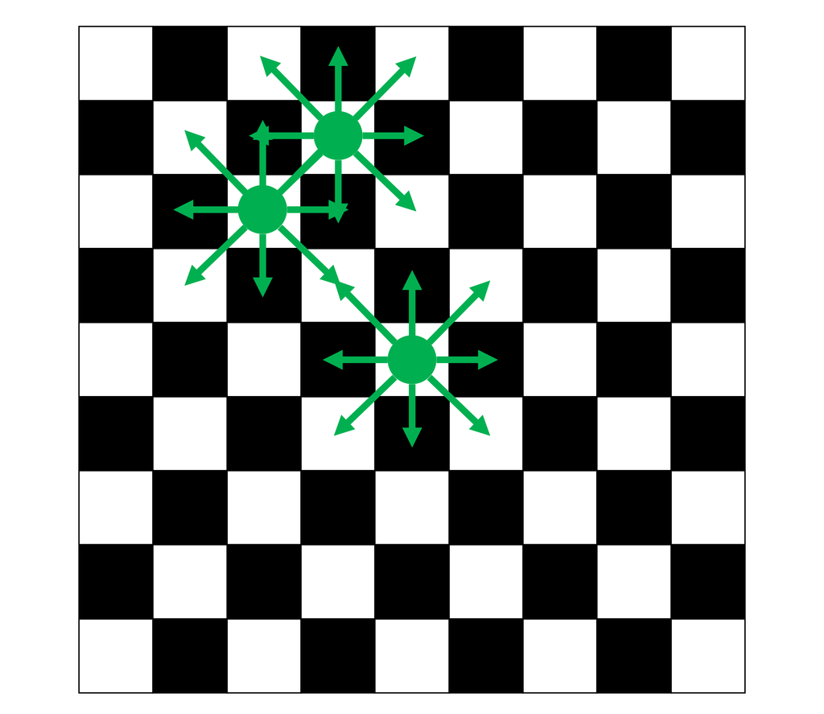

In graph lingo: We have one (or more) disjoint connected subgraph(s)

## Our case study

Say we are interested in clusters of citizens’ **party preferences** and associations with covariates such as **rent prices** or **immigrant shares**.

Again, we will focus on Cologne, utilizing **voting districts** instead of city districts this time.

## Voting districts

```r
voting_districts <-
  sf::st_read("./data/Stimmbezirk.shp") |>
  dplyr::mutate(
    district_id = as.numeric(nummer)
    ) |>
  dplyr::select(district_id, Shape_Area, geometry)

head(voting_districts, 2)
```

```
Simple feature collection with 2 features and 2 fields
Geometry type: MULTIPOLYGON
Dimension:     XY
Bounding box:  xmin: 354181.4 ymin: 5642934 xmax: 356401.7 ymax: 5644951
Projected CRS: ETRS89 / UTM zone 32N
  district_id Shape_Area                       geometry
1       10205   363417.6 MULTIPOLYGON (((354878.4 56...
2       10213   161963.0 MULTIPOLYGON (((356057.1 56...
```

## Federal elections 2021

```r
btw21_votes <-
  glue::glue(
    "https://www.stadt-koeln.de/wahlen/bundestagswahl/09-2021/praesentation/\\
    Open-Data-Bundestagswahl476.csv"
  ) |>
  readr::read_csv2() |>
  dplyr::mutate(
    district_id = as.numeric(`gebiet-nr`),
    valid_votes = `F`,
    cdu_share = (F1 / valid_votes) * 100,
    spd_share = (F2 / valid_votes) * 100,
    fdp_share = (F3 / valid_votes) * 100,
    afd_share = (F4 / valid_votes) * 100,
    greens_share = (F5 / valid_votes) * 100,
    linke_share = (F6 / valid_votes) * 100,
    .keep = "none"
  )

head(btw21_votes, 2)
```

```
# A tibble: 2 × 8
  district_id valid_votes cdu_share spd_share fdp_share afd_share greens_share
        <dbl>       <dbl>     <dbl>     <dbl>     <dbl>     <dbl>        <dbl>
1       10101         543      13.1      21.9      8.10      4.24         36.6
2       10102         551      11.4      22.0     11.3       2.90         36.5
# ℹ 1 more variable: linke_share <dbl>
```

## Federal elections 2021

We create additional factor variables for highest and second-highest vote shares.

```r
btw21_votes <- btw21_votes |>
  dplyr::rowwise() |>
  dplyr::mutate(
    highest_vote = factor(
      sub(
        "_share$",
        "",
        names(dplyr::pick(dplyr::ends_with("_share")))[
          order(
            dplyr::c_across(dplyr::ends_with("_share")),
            decreasing = TRUE
          )[1]
        ]
      )
    ),
    second_highest_vote = factor(
      sub(
        "_share$",
        "",
        names(dplyr::pick(dplyr::ends_with("_share")))[
          order(
            dplyr::c_across(dplyr::ends_with("_share")),
            decreasing = TRUE
          )[2]
        ]
      )
    )
  ) |>
  dplyr::ungroup()

table(btw21_votes$highest_vote)
```

```
greens    cdu    spd
   420    130    399
```

## Simple ID matching to link data

```r
election_results <-
  dplyr::left_join(
    voting_districts,
    btw21_votes,
    by = "district_id"
  )

head(election_results, 2)
```

```
Simple feature collection with 2 features and 11 fields
Geometry type: MULTIPOLYGON
Dimension:     XY
Bounding box:  xmin: 354181.4 ymin: 5642934 xmax: 356401.7 ymax: 5644951
Projected CRS: ETRS89 / UTM zone 32N
  district_id Shape_Area valid_votes cdu_share spd_share fdp_share afd_share
1       10205   363417.6         462   9.74026  17.31602 11.255411  2.597403
2       10213   161963.0         561  11.76471  23.70766  8.912656  1.247772
  greens_share linke_share highest_vote second_highest_vote
1     41.99134   10.173160       greens                 spd
2     40.81996    9.447415       greens                 spd
                        geometry
1 MULTIPOLYGON (((354878.4 56...
2 MULTIPOLYGON (((356057.1 56...
```

## Do vote shares spatially cluster?

```r
plot_data <- election_results |>
  tidyr::pivot_longer(
    cols = ends_with("_share"),
    names_to = "party",
    values_to = "vote_share"
  ) |>
  mutate(
    party = sub("_share$", "", party),
    party = factor(party)
  )

ggplot(plot_data) +
  geom_sf(aes(fill = vote_share), color = NA) +
  facet_wrap(~ party, nrow = 2, ncol = 3) +
  scale_fill_viridis_c() +
  theme_void() +
  labs(fill = "Vote share")
```

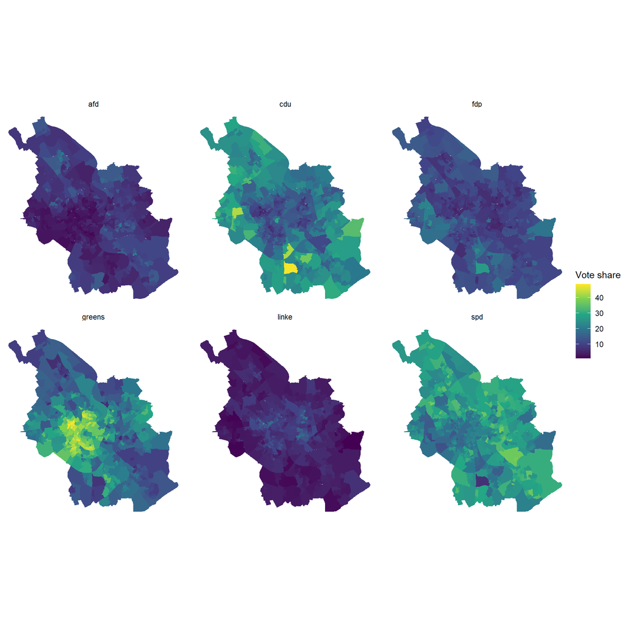

## Pull in German Census data

```r
immigrants_cologne <- terra::rast("./data/immigrants_cologne.tif")
inhabitants_cologne <- terra::rast("./data/inhabitants_cologne.tif")

immigrants_cologne  <- terra::subst(immigrants_cologne,  from = -9, to = NA)
inhabitants_cologne <- terra::subst(inhabitants_cologne, from = -9, to = NA)

immigrant_share_cologne <- (immigrants_cologne / inhabitants_cologne)*100

age_rast <- terra::rast("./data/census22_age_avg.tif")
rent_rast <- terra::rast("./data/census22_rent_avg.tif")
```

## It’s raster data

```r
ggplot() +
  tidyterra::geom_spatraster(
    data = rent_rast
    ) +
  scale_fill_viridis_c()
```

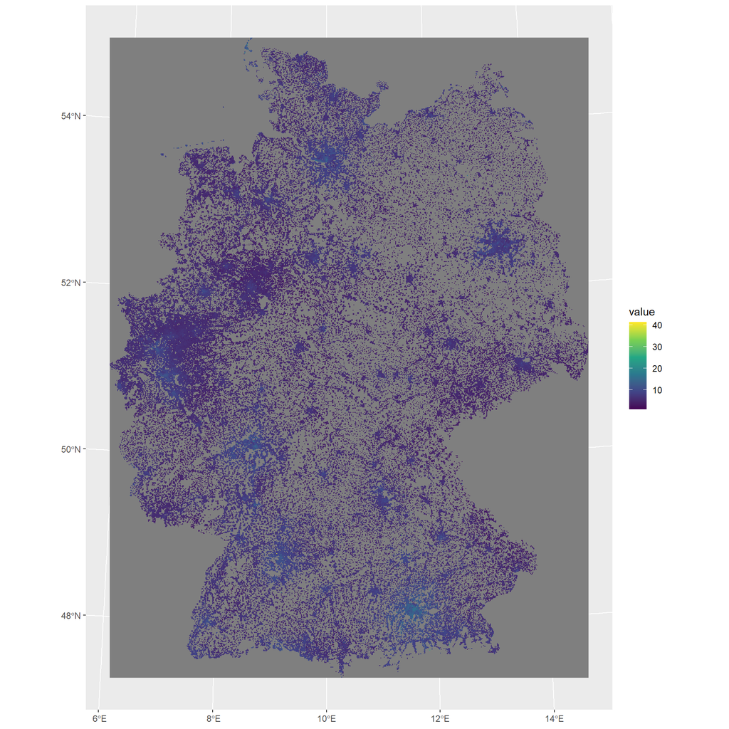

## Side quest: Aggregating raster by vector

As the voting (vector) data differs from the Census raster data, we cannot use simple ID matching like before.

- We have to rely on spatial linking techniques
- We could use `terra::extract()`
  - But as a default, it only captures raster cells as a whole and not their spatial fraction
  - Which would be honestly okay for most applications
  - But we can also aggregate more precisely with `exactextractr::exact_extract()`

## `exactextractr::exact_extract()`!

```r
election_results <-
  election_results |>
  dplyr::mutate(
    immigrant_share =
      exactextractr::exact_extract(
        immigrant_share_cologne, election_results, 'mean', progress = FALSE
      ),
    inhabitants =
      exactextractr::exact_extract(
        inhabitants_cologne, election_results, 'mean', progress = FALSE
      ),
    age_avg =
      exactextractr::exact_extract(
        age_rast, election_results, 'mean', progress = FALSE
      ),
    rent_avg =
      exactextractr::exact_extract(
        rent_rast, election_results, 'mean', progress = FALSE
      )
  )

head(election_results, 2)
```

```
Simple feature collection with 2 features and 15 fields
Geometry type: MULTIPOLYGON
Dimension:     XY
Bounding box:  xmin: 354181.4 ymin: 5642934 xmax: 356401.7 ymax: 5644951
Projected CRS: ETRS89 / UTM zone 32N
  district_id Shape_Area valid_votes cdu_share spd_share fdp_share afd_share
1       10205   363417.6         462   9.74026  17.31602 11.255411  2.597403
2       10213   161963.0         561  11.76471  23.70766  8.912656  1.247772
  greens_share linke_share highest_vote second_highest_vote
1     41.99134   10.173160       greens                 spd
2     40.81996    9.447415       greens                 spd
                        geometry immigrant_share inhabitants  age_avg rent_avg
1 MULTIPOLYGON (((354878.4 56...        25.80862    168.2629 38.59269 11.63169
2 MULTIPOLYGON (((356057.1 56...        23.67849    138.0017 40.87474 10.81500
```

## Voilà

```r
ggplot() +
  geom_sf(
    data = election_results,
    aes(fill = rent_avg)
  ) +
  scale_fill_viridis_c()
```

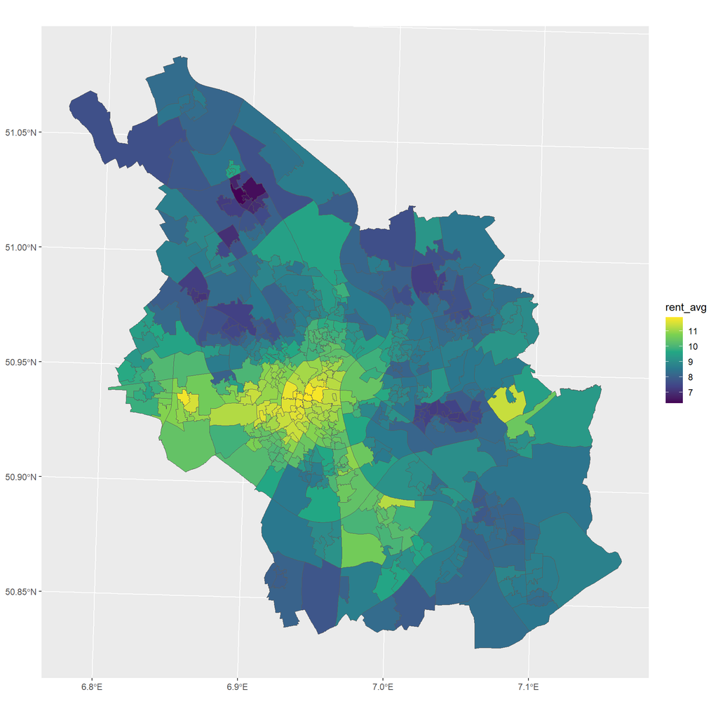

## How to test spatial autocorrelation

We now have to ask

- Do the spatial units relate to each other?
- If yes, in which way?
  - Only if they are bordering each other? (i.e., Queens or Rooks)
  - Or also if they are in proximity but not necessarily contiguous?

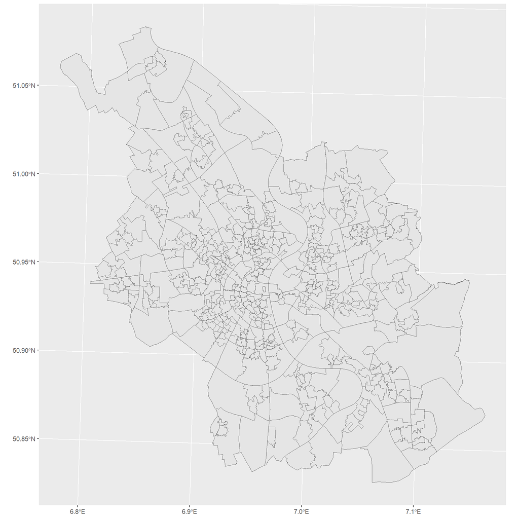

## Let’s try Queens neighborhoods

```r
queens_neighborhoods <-
  spdep::poly2nb(
    election_results,
    queen = TRUE
  )

summary(queens_neighborhoods)
```

```
Neighbour list object:
Number of regions: 543
Number of nonzero links: 3120
Percentage nonzero weights: 1.058169
Average number of links: 5.745856
Link number distribution:

  1   2   3   4   5   6   7   8   9  10  11  12  13  14  15
  1   9  48  89 137  97  70  43  19  17   4   5   2   1   1
1 least connected region:
69 with 1 link
1 most connected region:
387 with 15 links
```

## And alternative rook neighborhoods

```r
rook_neighborhoods <-
  spdep::poly2nb(
    election_results,
    queen = FALSE
  )

summary(rook_neighborhoods)
```

```
Neighbour list object:
Number of regions: 543
Number of nonzero links: 2922
Percentage nonzero weights: 0.9910157
Average number of links: 5.381215
Link number distribution:

  1   2   3   4   5   6   7   8   9  10  11  12  13  15
  3  14  51 111 145  97  55  32  20   7   4   2   1   1
3 least connected regions:
69 121 196 with 1 link
1 most connected region:
387 with 15 links
```

## Connected regions

```r
rook_lines <- rook_neighborhoods |>
  spdep::nb2lines(
    coords = sf::st_as_sfc(election_results),
    as_sf = TRUE
  )

queen_lines <- queens_neighborhoods |>
  spdep::nb2lines(
    coords = sf::st_as_sfc(election_results),
    as_sf = TRUE
  )

nb_points <- sf::st_centroid(queen_lines)

ggplot() +
  geom_sf(data = queen_lines, color = "#1b9e77",
          linewidth = 1, alpha = 0.6) +
  geom_sf(data = rook_lines, color = "#d95f02",
          linewidth = 1, alpha = 0.9,
          linetype = "dashed") +
  geom_sf(data = nb_points, size = 2) +
  theme_void()
```

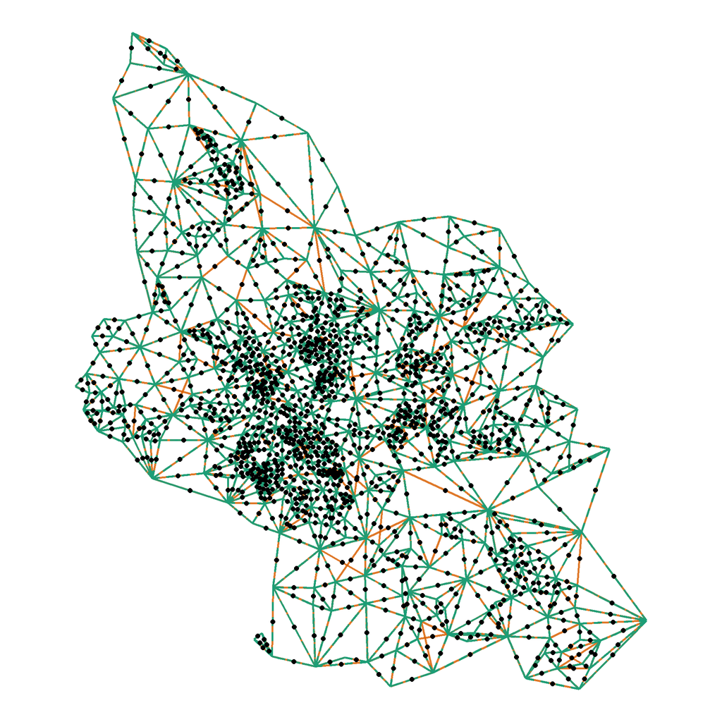

## Can we now start?

Unfortunately, we are not yet done with creating the links between neighborhoods. What we receive is, in principle, a huge matrix with connected observations.

```
   1 2 3 4 5 6 7 8 9 10
1  0 0 0 0 0 0 0 0 0  0
2  0 0 0 0 0 0 0 1 1  0
3  0 0 0 1 1 1 1 0 1  0
4  0 0 1 0 1 1 1 0 1  0
5  0 0 1 1 0 1 0 0 0  0
6  0 0 1 1 1 0 1 1 1  0
7  0 0 1 1 0 1 0 1 1  0
8  0 1 0 0 0 1 1 0 1  0
9  0 1 1 1 0 1 1 1 0  0
10 0 0 0 0 0 0 0 0 0  0
```

That’s nothing we could plug into a statistical model, such as a regression or the like (see next session).

## Step 2: Normalization

Normalization is the process of creating actual **spatial weights**. There is a debate on how to do it (Neumayer & Plümper, 2016)<sup>1</sup>. But nobody questions whether it should be done in the first place since, among others, it restricts the parameter space of the weights.

Without normalization:

- Units with many neighbors exert more influence
- Spatial lag depends on network density

**Goal**: make influence comparable across units

```
  1 2 3 4 5
1 0 0 0 0 0
2 0 0 0 0 0
3 0 0 0 1 1
4 0 0 1 0 1
5 0 0 1 1 0
```

```
[1] 0 0 2 2 2
```

[output not shown]

[output not shown]

[^2]: Neumayer, E., & Plümper, T. (2016). W. Political Science Research and Methods, 4(01), 175–193. https://doi.org/10.1017/psrm.2014.40

## Row-normalization

One of the standard procedures is row-normalization. It divides all individual weights (=connections between spatial units) $w_{ij}$ by the row-wise sum of of all other weights:

Each weight is normalized by the sum of its row:

$$w_{ij}^* = \frac{w_{ij}}{\sum_j w_{ij}}$$

## Effect of row-normalization

**Show R code**

```r
library(dplyr)
library(ggplot2)
library(ggpattern)

make_case <- function(focal_x, focal_y, title_text) {
  grid <- expand.grid(x = 1:5, y = 1:5) |>
    as_tibble()

  grid <- grid |>
    mutate(
      dist = abs(x - focal_x) + abs(y - focal_y),
      role = case_when(
        x == focal_x & y == focal_y ~ "focal",
        dist == 1 ~ "neighbor",
        TRUE ~ "other"
      )
    )

  n_nb <- sum(grid$role == "neighbor")

  grid |>
    mutate(
      weight = ifelse(role == "neighbor", 1 / n_nb, NA),
      label = case_when(
        role == "focal" ~ "i",
        role == "neighbor" ~ paste0("1/", n_nb),
        TRUE ~ ""
      ),
      example = title_text
    )
}

df <- bind_rows(
  make_case(3, 3, "Central cell\n4 neighbors → 1/4 each"),
  make_case(3, 5, "Edge cell\n3 neighbors → 1/3 each")
)

ggplot(df, aes(x, y)) +
  geom_tile(fill = "grey95", color = "white", linewidth = 1) +
  ggpattern::geom_tile_pattern(
    data = subset(df, role == "neighbor"),
    fill = "grey95",
    pattern = "stripe",
    pattern_fill = "lightgreen",
    pattern_colour = "lightgreen",
    pattern_density = 0.35,
    pattern_spacing = 0.03,
    color = "white",
    linewidth = 1
  ) +
  geom_tile(
    data = subset(df, role == "focal"),
    fill = "gold",
    color = "white",
    linewidth = 1
  ) +
  geom_text(aes(label = label), size = 5) +
  facet_wrap(~example) +
  coord_equal() +
  scale_y_reverse() +
  theme_void() +
  theme(
    strip.text = element_text(size = 11, face = "bold"),
    legend.position = "none"
  )
```

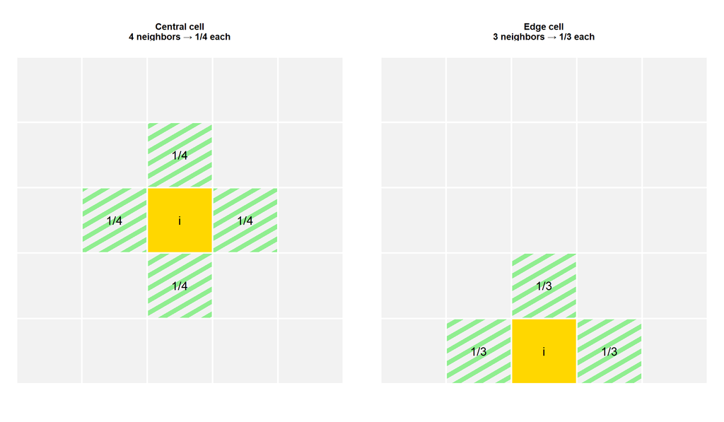

## Alternatives to row-normalization

**“B”** (Binary) - Keeps original neighbor structure

**“W”** (Row-standardized) - Row-normalized weights / Each unit’s weights sum to 1 / Interpretable as average of neighbors

**“C”** (Globally standardized) - Weights scaled so the total sum across all units equals n (number of observations) / Preserves global comparability

**“U”** (Equal to C but unscaled) - Similar structure to “C”, but total sum equals 1 / Less commonly used

**“S”** (Variance-stabilizing) - Adjusts weights to stabilize variance across units / Reduces influence of highly connected units

**“minmax”** - Scales weights by the minimum of the maximum row and column sums / Keeps weights bounded and comparable

## Apply row-normalization

```r
queens_W <- spdep::nb2listw(queens_neighborhoods, style = "W")

summary(queens_W)
```

```
Characteristics of weights list object:
Neighbour list object:
Number of regions: 543
Number of nonzero links: 3120
Percentage nonzero weights: 1.058169
Average number of links: 5.745856
Link number distribution:

  1   2   3   4   5   6   7   8   9  10  11  12  13  14  15
  1   9  48  89 137  97  70  43  19  17   4   5   2   1   1
1 least connected region:
69 with 1 link
1 most connected region:
387 with 15 links

Weights style: W
Weights constants summary:
    n     nn  S0       S1       S2
W 543 294849 543 201.1676 2261.458
```

## Tidyverse alternative: `sfdep` package

The [`sfdep`](https://cran.r-project.org/web/packages/sfdep/index.html) package provides a more `tidyverse`-compliant syntax to spatial weights. See:

```r
election_results <-
  election_results |>
  dplyr::mutate(
    neighbors = sfdep::st_contiguity(election_results), # queen neighborhoods by default
    weights = sfdep::st_weights(neighbors)
  )

head(election_results, 2)
```

```
Simple feature collection with 2 features and 17 fields
Geometry type: MULTIPOLYGON
Dimension:     XY
Bounding box:  xmin: 354181.4 ymin: 5642934 xmax: 356401.7 ymax: 5644951
Projected CRS: ETRS89 / UTM zone 32N
  district_id Shape_Area valid_votes cdu_share spd_share fdp_share afd_share
1       10205   363417.6         462   9.74026  17.31602 11.255411  2.597403
2       10213   161963.0         561  11.76471  23.70766  8.912656  1.247772
  greens_share linke_share highest_vote second_highest_vote
1     41.99134   10.173160       greens                 spd
2     40.81996    9.447415       greens                 spd
                        geometry immigrant_share inhabitants  age_avg rent_avg
1 MULTIPOLYGON (((354878.4 56...        25.80862    168.2629 38.59269 11.63169
2 MULTIPOLYGON (((356057.1 56...        23.67849    138.0017 40.87474 10.81500
                           neighbors
1 16, 18, 22, 25, 458, 459, 460, 462
2                   8, 9, 11, 48, 49
                                                 weights
1 0.125, 0.125, 0.125, 0.125, 0.125, 0.125, 0.125, 0.125
2                                0.2, 0.2, 0.2, 0.2, 0.2
```

## Step 3: Tests of spatial autocorrelation

- Global measures consider the **average level of spatial autocorrelation across all observations**
- Bias can be induced through **edge effects** where important parts of the spatial process fall outside the study area (compare to left- and right-censoring longitudinal data)

Global tests in this session include:

1. **Join-count tests** for categorical data
2. **Moran’s I**
3. **Geary’s C**

## Join-count tests for categorical data

- Evaluates whether adjacent areas share the **same category**
- The test counts joins: pairs of neighboring polygons (defined by your **weights matrix**)
- It compares observed joins to what would be expected under **spatial randomness** (null hypothesis)

$$z_{kl} =
\frac{J_{kl} - \operatorname{E}(J_{kl})}
{\sqrt{\operatorname{Var}(J_{kl})}}$$

where:

- $J_{kl}$ = observed number of joins between categories $k$ and $l$
- $\operatorname{E}(J_{kl})$ = expected joins under spatial randomness
- $\operatorname{Var}(J_{kl})$ = variance under the null hypothesis

## Join-count tests for categorical data

- Same-category joins higher than expected: **spatial clustering**
- Mixed-category joins lower than expected: **spatial segregation**
- Mixed-category joins higher than expected: **spatial dispersion**

```r
args(spdep::joincount.multi)
```

```
function (fx, listw, zero.policy = attr(listw, "zero.policy"),
    spChk = NULL, adjust.n = TRUE)
NULL
```

## Join-count tests for categorical data

```r
spdep::joincount.multi(
  election_results$highest_vote,
  listw = queens_W
)
```

```
              Joincount  Expected  Variance  z-value
greens:greens  91.09174  51.16236   4.05352  19.8325
cdu:cdu        13.52522   3.71956   0.56577  13.0364
spd:spd        88.30887  54.24908   4.16068  16.6978
cdu:greens     11.94046  27.86716   3.21308  -8.8852
spd:greens     40.86432 105.80812  10.29932 -20.2364
spd:cdu        25.76939  28.69373   3.26434  -1.6186
Jtot           78.57417 162.36900  11.15460 -25.0894
```

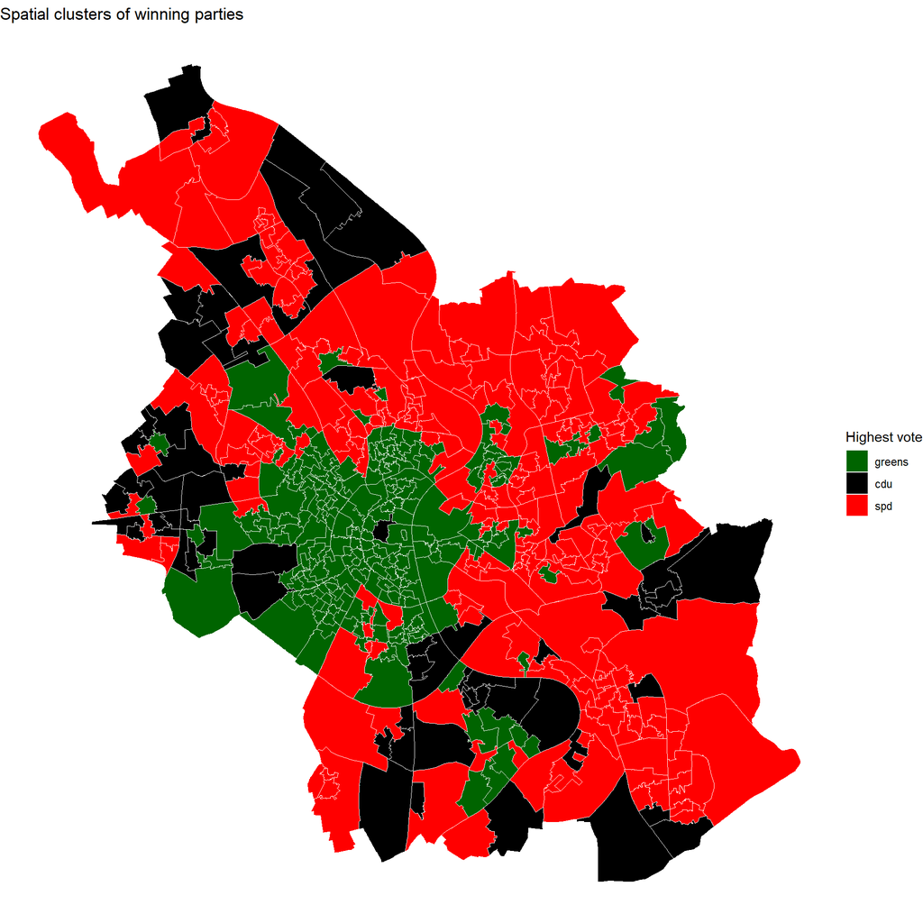

```r
ggplot(election_results) +
  geom_sf(aes(fill = highest_vote), color = "white", linewidth = 0.1) +
  scale_fill_manual(
    values = c(
      "greens" = "darkgreen",
      "spd" = "red",
      "cdu" = "black"
    )
  ) +
  theme_void() +
  labs(
    fill = "Highest vote",
    title = "Spatial clusters of winning parties"
  )
```

## Step 3: Tests of spatial autocorrelation

$$I=\frac{N}{\sum_{i=1}^N\sum_{j=1}^Nw_{ij}}\frac{\sum_{i=1}^{N}\sum_{j=1}^Nw_{ij}(x_i-\bar{x})(x_j-\bar{x})}{\sum_{i=1}^N(x_i-\bar{x})^2}$$

- Most and foremost, **Moran’s I** use the previously created weights between all spatial unit pairs $w_{ij}$.
- It weights deviations from an overall mean value of connected pairs according to the strength of the modeled spatial relations.
- Moran’s I can be interpreted as a correlation coefficient with a **range from -1 to +1**

## Example patterns

**Show R code**

```r
library(dplyr)
library(ggplot2)
library(spdep)
library(tibble)

# 5x5 grid and rook neighbours
n <- 5
grid <- expand.grid(x = 1:n, y = 1:n) |>
  as_tibble()

nb <- spdep::cell2nb(nrow = n, ncol = n, type = "rook")
lw <- spdep::nb2listw(nb, style = "W", zero.policy = TRUE)

# helper to compute Moran's I
moran_I <- function(v) {
  spdep::moran(
    x = v,
    listw = lw,
    n = length(v),
    S0 = spdep::Szero(lw),
    zero.policy = TRUE
  )$I
}

# pattern close to +1: iteratively smooth a random field
make_positive_pattern <- function(target = 0.95, max_iter = 200) {
  set.seed(123)
  v <- rnorm(nrow(grid))

  for (i in seq_len(max_iter)) {
    v <- 0.35 * v + 0.65 * spdep::lag.listw(lw, v, zero.policy = TRUE)
    if (moran_I(v) > target) break
  }

  as.numeric(scale(v))
}

# pattern close to 0: search for a near-random arrangement
make_zero_pattern <- function(tol = 0.05, max_iter = 10000) {
  best_v <- NULL
  best_I <- Inf

  for (i in seq_len(max_iter)) {
    v <- sample.int(nrow(grid))
    I <- moran_I(v)

    if (abs(I) < abs(best_I)) {
      best_v <- v
      best_I <- I
    }

    if (abs(I) <= tol) break
  }

  as.numeric(scale(best_v))
}

# pattern close to -1: checkerboard
v_neg <- ifelse((grid$x + grid$y) %% 2 == 0, 1, -1)
v_zero <- make_zero_pattern()
v_pos <- make_positive_pattern()

# combine for plotting
plot_df <- bind_rows(
  grid |>
    mutate(
      value = v_neg,
      panel = sprintf("Moran's I close to -1\nDispersion pattern", moran_I(v_neg))
    ),
  grid |>
    mutate(
      value = v_zero,
      panel = sprintf("Moran's I close to 0\nRandom pattern", moran_I(v_zero))
    ),
  grid |>
    mutate(
      value = v_pos,
      panel = sprintf("Moran's I close to 1\nClustering pattern", moran_I(v_pos))
    )
)

ggplot(plot_df, aes(x, y, fill = value)) +
  geom_tile(color = "white", linewidth = 1) +
  facet_wrap(~panel, nrow = 1) +
  coord_equal() +
  scale_y_reverse() +
  scale_fill_gradient2(
    low = "steelblue",
    mid = "white",
    high = "firebrick",
    midpoint = 0
  ) +
  theme_void() +
  theme(
    strip.text = element_text(size = 12, face = "bold"),
    legend.position = "none"
  )
```

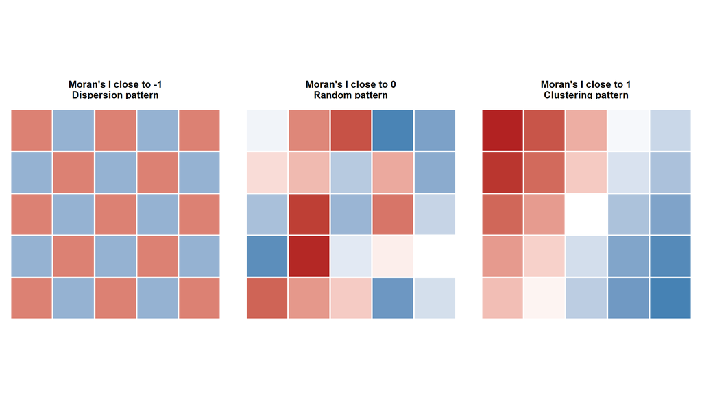

## Moran’s I in `spdep`

```r
spdep::moran.test(
  election_results$rent_avg,
  listw = queens_W
)
```

```
    Moran I test under randomisation

data:  election_results$rent_avg
weights: queens_W

Moran I statistic standard deviate = 33.387, p-value < 2.2e-16
alternative hypothesis: greater
sample estimates:
Moran I statistic       Expectation          Variance
     0.8661742414     -0.0018450185      0.0006759199
```

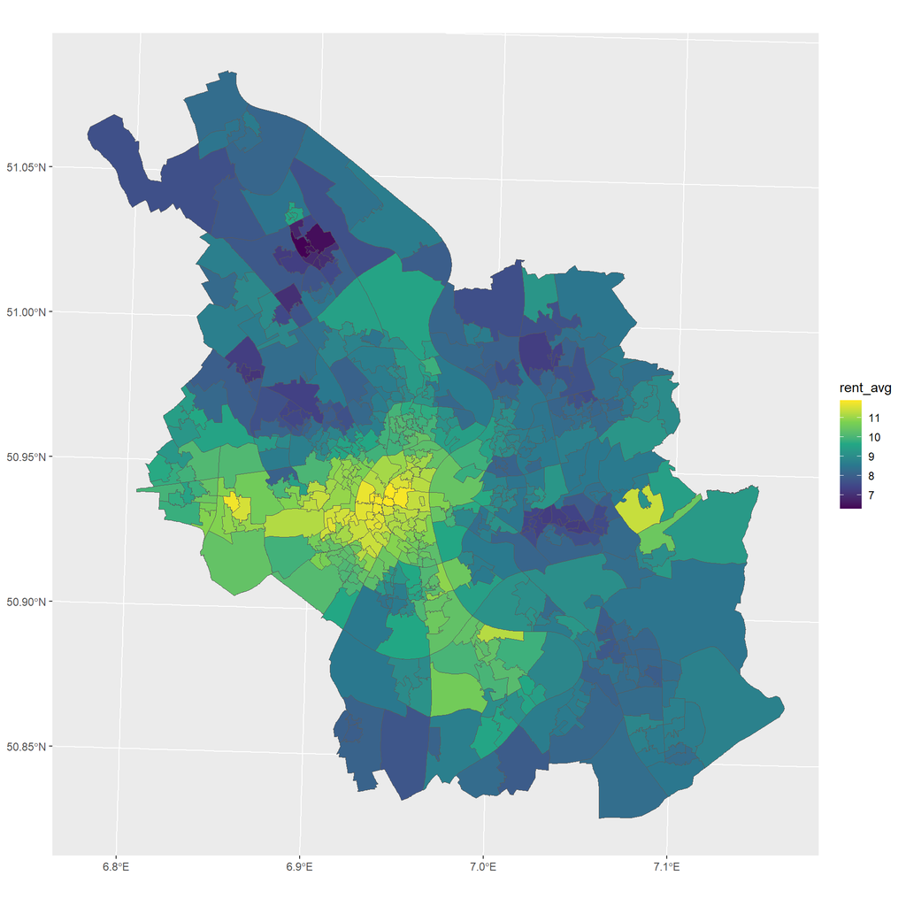

## Moran scatterplot

```r
mp <- spdep::moran.plot(
  x = election_results$rent_avg,
  listw = queens_W,
  labels = election_results$district_id,
  xlab = "Rent average",
  ylab = "Spatial lag of rent average"
)

x_mean <- mean(election_results$rent_avg, na.rm = TRUE)
lag_rent <- spdep::lag.listw(queens_W, election_results$rent_avg)
y_mean <- mean(lag_rent, na.rm = TRUE)

x_range <- range(mp$x, na.rm = TRUE)
y_range <- range(mp$wx, na.rm = TRUE)

x_left  <- mean(c(x_range[1], x_mean))
x_right <- mean(c(x_mean, x_range[2]))

text(x_right, y_range[2], "High–High", pos = 1, col = "red")
text(x_left,  y_range[2], "Low–High",  pos = 1, col = "red")
text(x_left,  y_range[1], "Low–Low",   pos = 3, col = "red")
text(x_right, y_range[1], "High–Low",  pos = 3, col = "red")
```

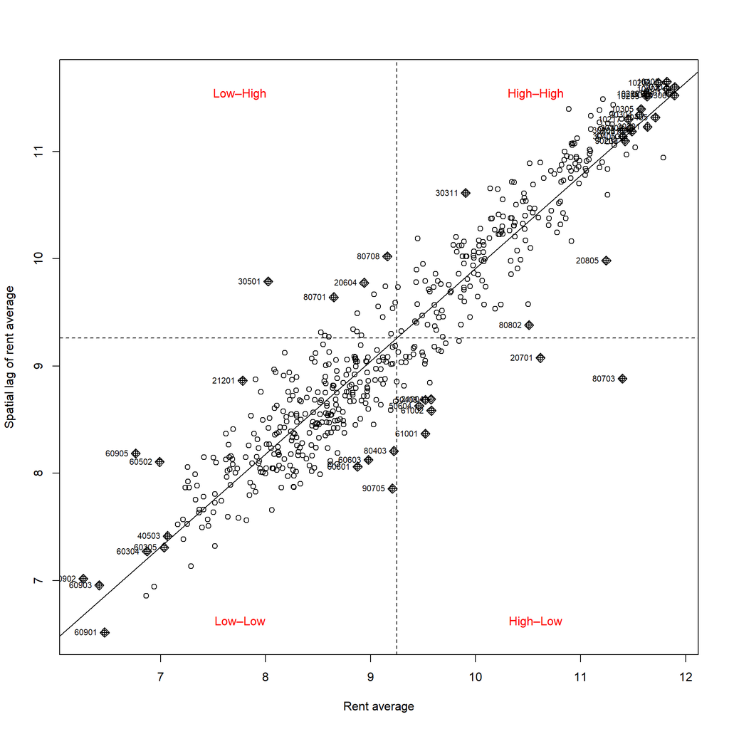

## Moran’s I in `sfdep`

```r
library(magrittr)

election_results %$%
  sfdep::global_moran_test(rent_avg, neighbors, weights)
```

```
    Moran I test under randomisation

data:  x
weights: listw

Moran I statistic standard deviate = 33.387, p-value < 2.2e-16
alternative hypothesis: greater
sample estimates:
Moran I statistic       Expectation          Variance
     0.8661742414     -0.0018450185      0.0006759199
```

## Test of spatial autocorrelation: Geary’s C

Moran’s I is based on **covariance** between values and their spatial lag and captures overall similarity patterns. It can produce issues when there are only local clusters of spatial interdependence in the data. An alternative is the use of `Geary's C`:

$$C=\frac{(N-1)\sum_i\sum_jw_{ij}(x_i-x_j)^2}{2\sum_{i=1}^N\sum_{j=1}^Nw_{ij}\sum_i(x_i-\bar{x})^2}$$

It is based on **squared differences** between neighbors and emphasizes local dissimilarities.

Geary’s C only produces values between 0 and 2:

- values near 0 = positive spatial autocorrelation;
- values near 1 = no spatial autocorrelation;
- values near 2 = negative spatial autocorrelation.

## Geary’s C in `spdep`

```r
spdep::geary.test(
  election_results$rent_avg,
  listw = queens_W
)
```

```
    Geary C test under randomisation

data:  election_results$rent_avg
weights: queens_W

Geary C statistic standard deviate = 31.5, p-value < 2.2e-16
alternative hypothesis: Expectation greater than statistic
sample estimates:
Geary C statistic       Expectation          Variance
     0.1291293820      1.0000000000      0.0007643565
```

## Geary’s C in `sfdep`

```r
election_results %$%
  sfdep::global_c_test(rent_avg, neighbors, weights)
```

```
    Geary C test under randomisation

data:  x
weights: listw

Geary C statistic standard deviate = 31.5, p-value < 2.2e-16
alternative hypothesis: Expectation greater than statistic
sample estimates:
Geary C statistic       Expectation          Variance
     0.1291293820      1.0000000000      0.0007643565
```

## Measures of local spatial autocorrelation: LISA clusters

We show you the `sfdep` package because it provides nice functions to calculate *local* measures of spatial autocorrelation. One popular choice is the estimation of Local Indicators of Spatial Autocorrelation (i.e., LISA clusters). Most straightforwardly, they can be interpreted as case-specific indicators of spatial autocorrelation:

$$I_i=\frac{x_i-\bar{x}}{\frac{\sum_{i-1}^N(x_i-\bar{x})^2}{N}}\sum_{j=1}^Nw_{ij}(x_j-\bar{x})$$

## Local Moran’s I in `sfdep`

```r
lisa <-
  election_results |>
  dplyr::mutate(
    lisa = sfdep::local_moran(rent_avg, neighbors, weights)
  ) |>
  tidyr::unnest(cols = lisa)

head(lisa, 2)
```

```
Simple feature collection with 2 features and 29 fields
Geometry type: MULTIPOLYGON
Dimension:     XY
Bounding box:  xmin: 354181.4 ymin: 5642934 xmax: 356401.7 ymax: 5644951
Projected CRS: ETRS89 / UTM zone 32N
# A tibble: 2 × 30
  district_id Shape_Area valid_votes cdu_share spd_share fdp_share afd_share
        <dbl>      <dbl>       <dbl>     <dbl>     <dbl>     <dbl>     <dbl>
1       10205    363418.         462      9.74      17.3     11.3       2.60
2       10213    161963.         561     11.8       23.7      8.91      1.25
# ℹ 23 more variables: greens_share <dbl>, linke_share <dbl>,
#   highest_vote <fct>, second_highest_vote <fct>, geometry <MULTIPOLYGON [m]>,
#   immigrant_share <dbl>, inhabitants <dbl>, age_avg <dbl>, rent_avg <dbl>,
#   neighbors <nb>, weights <list>, ii <dbl>, eii <dbl>, var_ii <dbl>,
#   z_ii <dbl>, p_ii <dbl>, p_ii_sim <dbl>, p_folded_sim <dbl>, skewness <dbl>,
#   kurtosis <dbl>, mean <fct>, median <fct>, pysal <fct>
```

## It’s also nice for mapping

```r
ggplot() +
  geom_sf(
    data = lisa,
    aes(fill = ii)
  ) +
  scale_fill_viridis_c()
```

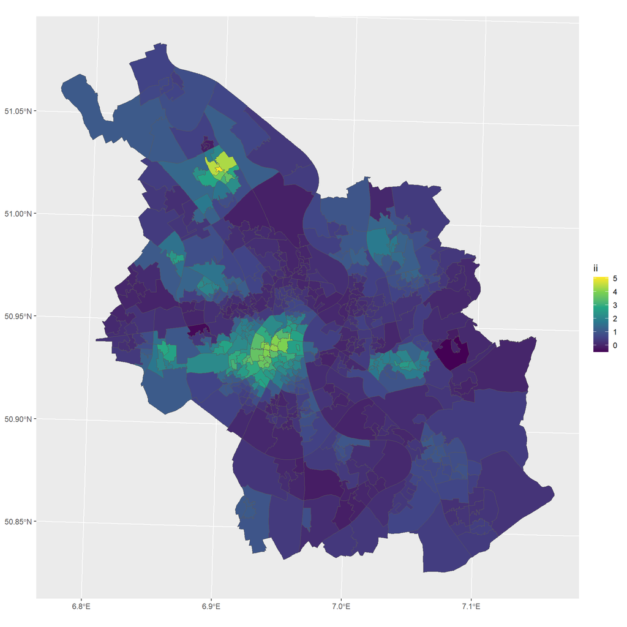

## It’s suitable for hot-spot analysis

```r
lisa <- lisa |>
  dplyr::mutate(
    lisa_cluster_rent = dplyr::if_else(
      p_folded_sim < 0.05,
      as.character(mean),
      "Not significant"
    ),
    lisa_cluster_rent = factor(
      lisa_cluster_rent,
      levels = c(
        "High-High",
        "Low-Low",
        "High-Low",
        "Low-High",
        "Not significant"
      )
    )
  )

ggplot(lisa) +
  geom_sf(aes(fill = lisa_cluster_rent), color = NA) +
  scale_fill_manual(
    values = c(
      "High-High" = "red",
      "Low-Low" = "blue",
      "High-Low" = "orange",
      "Low-High" = "lightgreen",
      "Not significant" = "grey90"
    ),
    drop = FALSE
  ) +
  theme_void() +
  labs(
    fill = "LISA cluster",
    title = "Local Moran clusters for average rent",
    subtitle = "Significance based on p_folded_sim < 0.05"
  )
```

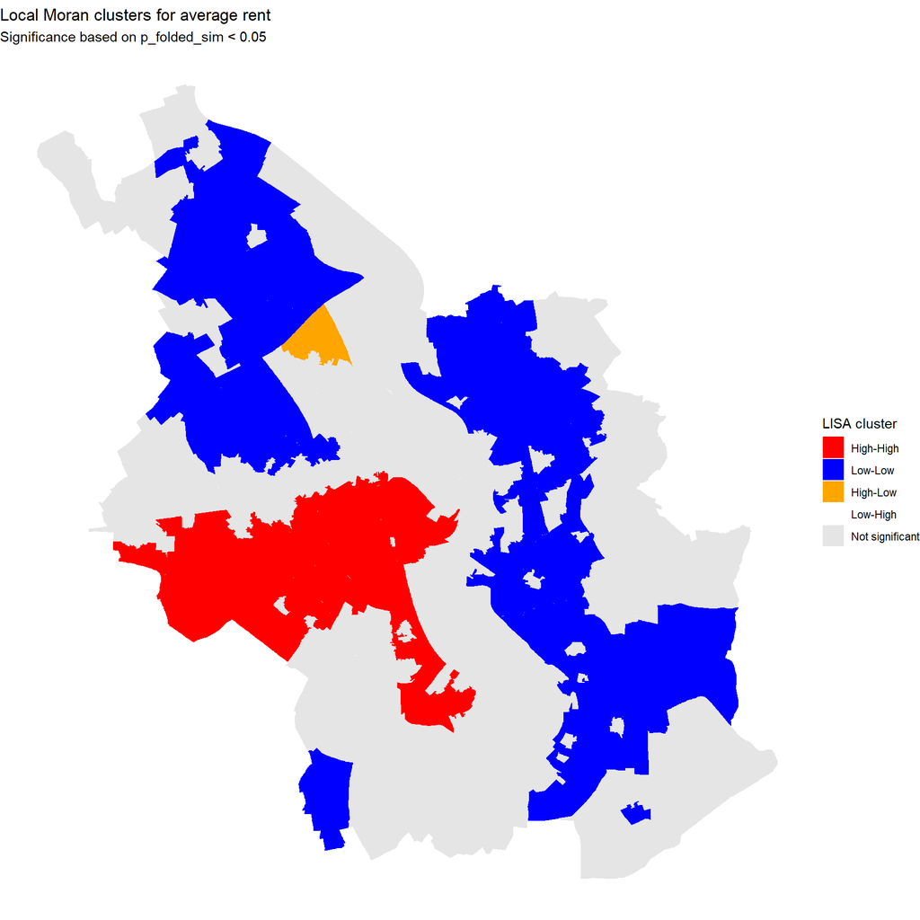

## Exercise 7: Neighborhood Matrices

[Exercise](https://stefanjuenger.github.io/gesis-workshop-geospatial-techniques-R-2026/exercises/7_Neighborhood_Matrices.html)

## One last bit: bivariate local Moran’s I

```r
lisa_bivariate <-
  election_results |>
  dplyr::mutate(
    lisa_bv = sfdep::local_moran_bv(
      cdu_share,
      rent_avg,
      neighbors,
      weights
    )
  ) |>
  tidyr::unnest(cols = lisa_bv)

head(lisa_bivariate)
```

```
Simple feature collection with 6 features and 19 fields
Geometry type: MULTIPOLYGON
Dimension:     XY
Bounding box:  xmin: 354181.4 ymin: 5642395 xmax: 357543.3 ymax: 5644951
Projected CRS: ETRS89 / UTM zone 32N
# A tibble: 6 × 20
  district_id Shape_Area valid_votes cdu_share spd_share fdp_share afd_share
        <dbl>      <dbl>       <dbl>     <dbl>     <dbl>     <dbl>     <dbl>
1       10205    363418.         462      9.74      17.3     11.3       2.60
2       10213    161963.         561     11.8       23.7      8.91      1.25
3       10218    329149.         559     12.9       19.5     11.4       1.43
4       10211     91481.         668      8.23      20.5      7.04      1.05
5       10210    157818.         640     11.2       22.3      7.97      2.34
6       10209     97306.         662      8.46      20.4      7.55      2.42
# ℹ 13 more variables: greens_share <dbl>, linke_share <dbl>,
#   highest_vote <fct>, second_highest_vote <fct>, geometry <MULTIPOLYGON [m]>,
#   immigrant_share <dbl>, inhabitants <dbl>, age_avg <dbl>, rent_avg <dbl>,
#   neighbors <nb>, weights <list>, Ib <dbl>, p_sim <dbl>
```

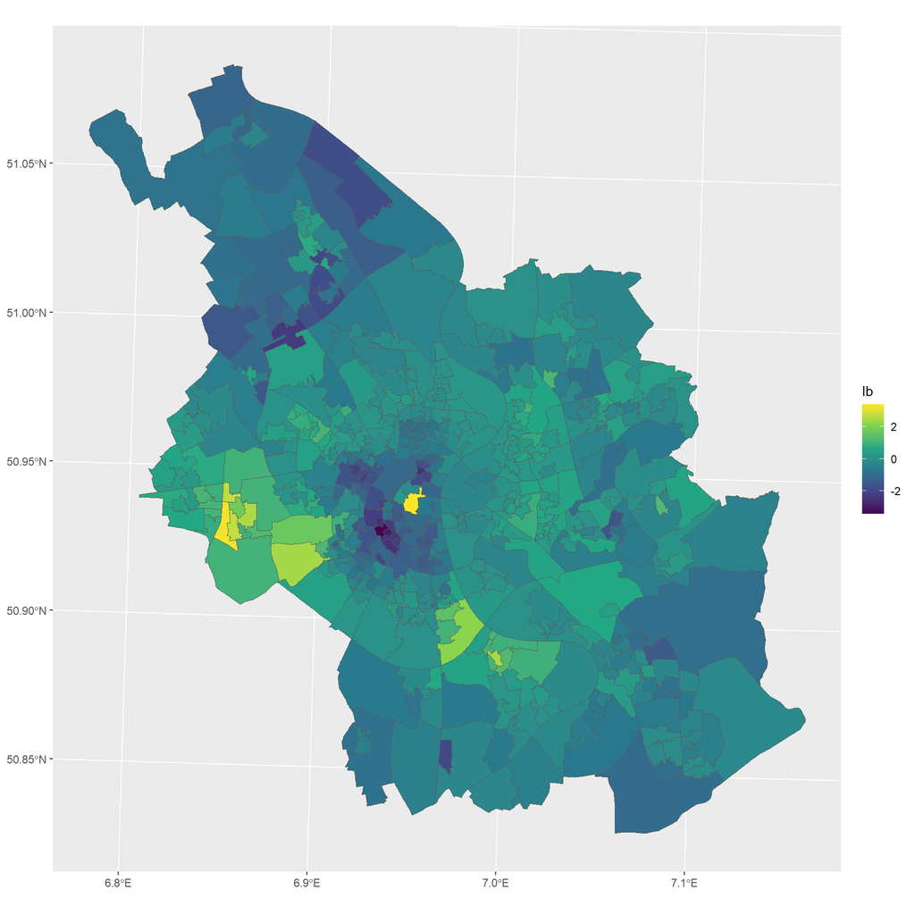

```r
ggplot() +
  geom_sf(
    data = lisa_bivariate,
    aes(fill = Ib)
  ) +
  scale_fill_viridis_c()
```

## Wrap up

You now know how to model the connectedness of spatial units, investigate spatial autocorrelation globally and locally, and map it.

There’s way more, particularly regarding spatial weights (see exercise), clustering techniques (e.g., Hot Spot Analysis), or autocorrelation with more than one or two variables.

**Nevertheless, now we know our data are spatially autocorrelated. Let’s try to find out why this is the case via some spatial econometrics**